# Project 4

STATS 220 Semester One 2023

Rudklao Raviyan

2023-05-13

## Introduction

For this project, I would like to focus on who I have communicated with the most during the time period when the data was extracted. I have categorized the emails I have been receiving by the number of characters and the time period. My aim for this project is for the person who glances at my charts to obtain as much information as possible.

For the **first chart**, I would like the reader to have an overall understanding of who has been sending me emails and under which group, such as from Canvas, universities, between fellow students, and other emails. This allows the reader to have a quick glance and easily see who I have been receiving emails from the most and the least. To create the chart, I chose a bar chart and reordered them in ascending order. I removed the grey background so that the color theme from the viridislite package popped, but I left the gridlines on the chart for easy figure reading.

For the **second chart**, I used a stacked bar chart so that the reader can have a quick glance and see who sent me the most emails during each month. The color codings for each sender correspond to the previous chart.

For the **third chart**, I used a scatter plot with a triangle indicating the mean character length. With this chart, I would like to explore by adding multiple layers on ggplot. The scatter plot allows the reader to see the distribution of the number of characters.

Regarding the animation graph, I initially wanted an animated stacked bar chart during the time period to observe how incoming emails change and identify who has sent me the most emails. However, after trying and figuring out the transition_* layer, state, and other related functions, I decided to go with a simple line chart with the stacked bar graphs animated together. It’s not what I was hoping to achieve, but at least the reader can see the changes in incoming emails over the time period and the proportion of senders.

## Visualisations

**Chart 1** shows individuals who sent emails to my inbox, ranked in ascending order by group..

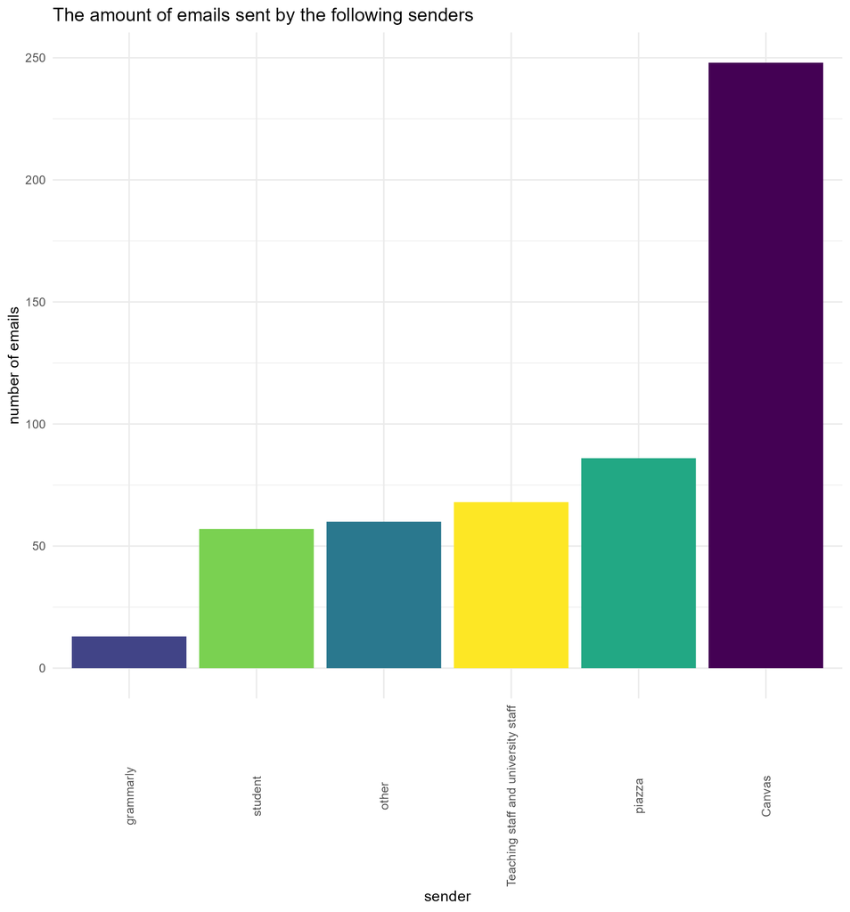

**Chart 2** shows the total number of emails received each month, along with the proportion of the senders.

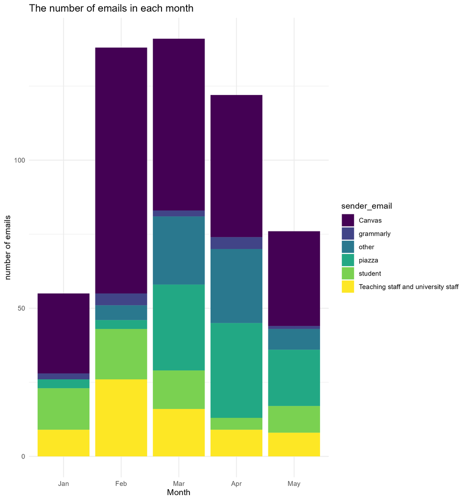

**Chart3** shows the distribution of the number of characters in emails sent by each sender group, with triangles indicating the mean value.

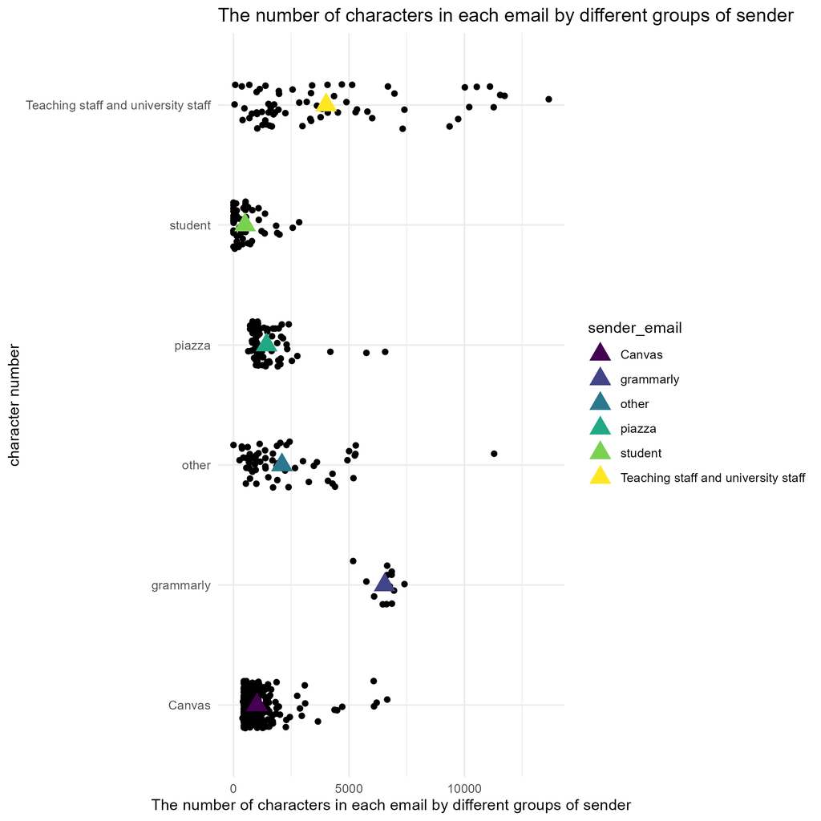

**The animation** shows the changes in incoming emails throughout the time period.

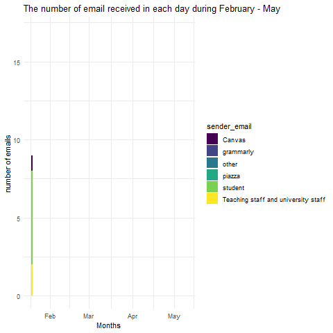

## Learning reflection

For this project, I learned the power of ggplot functions, enabling the creation of various data visualizations based on the information we aim to convey. To convey the story I intended, I had to be critical of the designs of my charts and consider how to deliver the most information at a glance. Throughout this project, I was inspired by the quote, *“A picture is worth a thousand words,”* and I strived to be creative with my chart designs.

Regarding creativity, I utilized the ViridisLite package to employ a vibrant color palette for my charts. It assigned a specific color to each sender group, maintaining consistency across all the charts. This approach ensures that the reader can easily recognize the sender group.

Looking ahead, I aspire to delve deeper into the capabilities of RStudio and the R language, exploring additional tools for data and analysis.

## Appendix

```r
library(tidyverse)
library(ggplot2)
library(gganimate)
library(viridisLite)



#story: In each month, who did I receive email from the most, and who wrote the longest email

#url <-("https://docs.google.com/spreadsheets/d/e/2PACX-1vSDsPLEUPFsCyTmHqpDK0eiw0zkXLOsOEfSLH3upravNJ4Usxp8lG5obLMnJynPsZ9P5mZycP4DPj4F/pub?output=csv")

url <- ("https://docs.google.com/spreadsheets/d/e/2PACX-1vSDsPLEUPFsCyTmHqpDK0eiw0zkXLOsOEfSLH3upravNJ4Usxp8lG5obLMnJynPsZ9P5mZycP4DPj4F/pub?gid=0&single=true&output=csv")
email_data <- read_csv(url)

#removing sensitive information

email_data <- email_data %>% mutate(sender_email = case_when(
                      str_detect(email_from, "@aucklanduni.ac.nz") ~ "student",
                      str_detect(email_from, "rrav628") ~ "me",
                      str_detect(email_from, "auckland.ac.nz") ~ "Teaching staff and university staff",
                      str_detect(email_from, "piazza") ~ "piazza",
                      str_detect(email_from, "grammarly") ~ "grammarly",
                      str_detect(email_from, "notifications@instructure.com") ~ "Canvas",
                      TRUE ~ "other"),
                      receieve_email = case_when(
                        str_detect(email_from, "@aucklanduni.ac.nz") ~ "student",
                        str_detect(email_from, "rrav628") ~ "me",
                        str_detect(email_from, "auckland.ac.nz") ~ "Teaching staff and university staff",
                        str_detect(email_from, "piazza") ~ "piazza",
                        str_detect(email_from, "grammarly") ~ "grammarly",
                        str_detect(email_from, "notifications@instructure.com") ~ "Canvas",
                        TRUE ~ "other"),
                      email_character = nchar(email_body))

#remove emails and content
email_data <- email_data[,c(-1,-2,-4)]
#reorder months into a correct order
email_data$email_month <- factor(email_data$email_month, levels = c("Jan", "Feb", "Mar", "Apr", "May"))

#bar graph of sender

sender <- email_data %>%
  count(sender_email)

ggplot() +
  geom_col(data = sender,
           aes(x = reorder(sender_email, n),
               y = n))


#fit viridis colour to ggplot

g1 <- ggplot() +
  geom_col(data = sender,
           aes(x = reorder(sender_email, n),
               y = n))

g1 + scale_fill_viridis_d()

#didn't work

#instead of count, try group_by instead

sender2 <- email_data %>%
  group_by(sender_email) %>% summarise(n = n())

g2 <- ggplot() +
  geom_col(data = sender2,
           aes(x = reorder(sender_email, n),
               y = n,
               fill = viridis(6, option = "D")))

g2 + scale_fill_viridis_d()

#try 2
g3<- ggplot() +
  geom_col(data = sender2,
           aes(x = sender_email,
               y = n,
               fill = sender_email))

g3 + scale_fill_viridis_d()

#try3 - the final ones

g4 <- ggplot() +
  geom_col(data = sender2,
           aes(x = reorder(sender_email, n),
               y = n,
               fill = sender_email)) +
  scale_fill_viridis_d() +
  theme_minimal() +
  guides(fill = "none") +
  labs(x = "sender",
       y = "number of emails",
       title = "The amount of emails sent by the following senders") +
  theme(axis.text.x = element_text(angle = 90, vjust = 0.5))

ggsave("chart1.png", plot = g4)

#proportion of sender in each month

group_email_month <- email_data %>%
  count(email_month, sender_email)

#create bar chart with geom_bar

ggplot(data = group_email_month) +
  geom_bar(aes(x = email_month,
               y = n,
               fill = sender_email),
           stat = "identity",
           position = "stack")

#create bar chart with geom_col
ggplot(data = group_email_month) +

  geom_col(aes(x = email_month,
               y = n,
               fill = sender_email),
           stat = "identity",
           position = "stack")


#fit viridis colour palette, finall

group_email_month <- email_data %>%
  count(email_month, sender_email)

chart2 <- ggplot(data = group_email_month) +
  geom_bar(aes(x = email_month,
               y = n,
               fill = sender_email),
           stat = "identity",
           position = "stack") +
  scale_fill_viridis_d() +
  theme_minimal() +
  labs(x = "Month",
       y = "number of emails",
       title = "The number of emails in each month")

ggsave("chart2.png", plot = chart2)

#bar graph of email coming in each month

email_length <- email_data %>%
  group_by(sender_email) %>%
  summarise(mean_character = mean(email_character))

#visualise email length, final
#base layer
chart3 <- ggplot() +
  #add jitter
  geom_jitter(data = email_data,
              aes(x = email_character, y = sender_email),
              height = 0.2) +

  #later 2 - mean indicator using geompoint
  geom_point(data = email_length,
             aes(x = mean_character,
                 y = reorder(sender_email, -mean_character),
             colour = sender_email),
             size = 5,
             shape = 17) +
  scale_colour_viridis_d() +
  theme_minimal() +
  guides(fill = "none") +
  labs(x = "The number of characters in each email by different groups of sender",
       y = "character number",
       title = "The number of characters in each email by different groups of sender")

ggsave("chart3.png", plot = chart3, width = 8, height = 8)

# goal to create date time series graph

months_data <- email_data %>%
  mutate(incoming_email = email_data$email_date %>% str_sub(1,10) %>% as.Date(tryFormats = "%d/%m/%Y")) %>%
           count(incoming_email)

ggplot(months_data) +
  geom_line(aes(x = incoming_email,
                y = n))

Sys.setlocale("LC_TIME", "C")

months_data2 <- email_data %>%
  mutate(incoming_email = email_data$email_date %>% str_sub(1,10) %>% as.Date(tryFormats = "%d/%m/%Y")) %>%
  count(incoming_email, sender_email)

#try line graph - too messy
ggplot(months_data2) +
  geom_line(aes(x = incoming_email,
                y = n,
                color = sender_email))

#try bar graph
ggplot(months_data2) +
  geom_bar(aes(x = incoming_email,
                y = n,
                fill = sender_email),
           stat = "identity",
           position = "stack") +
  scale_fill_viridis_d() +
  theme_minimal() +
  labs(x = "The number of characters in each email by different groups of sender",
       y = "number of emails",
       title = "The number of email received in each day during February - May")


#create animation

animation <- ggplot(months_data2) +
  geom_bar(aes(x = incoming_email,
               y = n,
               fill = sender_email),
           stat = "identity",
           position = "stack") +
  scale_fill_viridis_d() +
  theme_minimal() +
  transition_states(incoming_email) +
  labs(x = "The number of characters in each email by different groups of sender",
       y = "number of emails",
       title = "The number of email received in each day during February - May")
animate(animation)

#change to transition_reveal

animation2 <- ggplot(months_data2) +

  #layer1 create stacked bar chart
  geom_bar(aes(x = incoming_email,
               y = n,
               fill = sender_email,
               group = incoming_email),
           stat = "identity",
           position = "stack") +
  scale_fill_viridis_d() +
  transition_reveal() +
  theme_minimal() +
  labs(x = "The number of characters in each email by different groups of sender",
       y = "number of emails",
       title = "The number of email received in each day during February - May")

animation2 +
  transition_reveal(incoming_email)
animate(animation2)

#transition layers

animation3 <- ggplot(months_data2) +

  #layer1 create stacked bar chart
  geom_bar(aes(x = incoming_email,
               y = n,
               fill = sender_email),
           stat = "identity",
           position = "stack") +
  scale_fill_viridis_d() +
  theme_minimal() +
  labs(x = "The number of characters in each email by different groups of sender",
       y = "number of emails",
       title = "The number of email received in each day during February - May")

animation3 +
  transition_layers(keep_layers = T, from_blank = T)
animate(animation3)

#None work, change the graph

g4 <- ggplot(months_data2) +
  geom_line(aes(x = incoming_email,
                y = n)) +
  theme_minimal() +
  labs(x = "Months",
       y = "number of emails",
       title = "The number of email received in each day during February - May")

g4 +
  transition_reveal(incoming_email)
animate()

# add stacked bar chart on the back ground and animated line chart together.

g5 <- ggplot(months_data2) +

  geom_bar(aes(x = incoming_email,
               y = n,
               fill = sender_email),
           stat = "identity",
           position = "stack") +
  scale_fill_viridis_d() +
  theme_minimal() +
  labs(x = "Months",
       y = "number of emails",
       title = "The number of email received in each day during February - May") +

  geom_line(aes(x = incoming_email,
                y = n)) +
  transition_reveal(incoming_email)
g5
animate(g5)

anim_save("animation1.gif", animation = g5)
```